# Skarlupka - Coding Exercise

Load and view the information about the gapminder dataset on “dslabs”

```r
library("dslabs")
data(gapminder)
help(gapminder)
```

View the structure of the gapminder data set.

```r
str(gapminder)
```

```
'data.frame':   10545 obs. of  9 variables:
 $ country         : Factor w/ 185 levels "Albania","Algeria",..: 1 2 3 4 5 6 7 8 9 10 ...
 $ year            : int  1960 1960 1960 1960 1960 1960 1960 1960 1960 1960 ...
 $ infant_mortality: num  115.4 148.2 208 NA 59.9 ...
 $ life_expectancy : num  62.9 47.5 36 63 65.4 ...
 $ fertility       : num  6.19 7.65 7.32 4.43 3.11 4.55 4.82 3.45 2.7 5.57 ...
 $ population      : num  1636054 11124892 5270844 54681 20619075 ...
 $ gdp             : num  NA 1.38e+10 NA NA 1.08e+11 ...
 $ continent       : Factor w/ 5 levels "Africa","Americas",..: 4 1 1 2 2 3 2 5 4 3 ...
 $ region          : Factor w/ 22 levels "Australia and New Zealand",..: 19 11 10 2 15 21 2 1 22 21 ...
```

View the summary of the gapminder dataset.

```r
summary(gapminder)
```

```
                country           year      infant_mortality
 Albania            :   57   Min.   :1960   Min.   :  1.50
 Algeria            :   57   1st Qu.:1974   1st Qu.: 16.00
 Angola             :   57   Median :1988   Median : 41.50
 Antigua and Barbuda:   57   Mean   :1988   Mean   : 55.31
 Argentina          :   57   3rd Qu.:2002   3rd Qu.: 85.10
 Armenia            :   57   Max.   :2016   Max.   :276.90
 (Other)            :10203                  NA's   :1453
 life_expectancy   fertility       population             gdp
 Min.   :13.20   Min.   :0.840   Min.   :3.124e+04   Min.   :4.040e+07
 1st Qu.:57.50   1st Qu.:2.200   1st Qu.:1.333e+06   1st Qu.:1.846e+09
 Median :67.54   Median :3.750   Median :5.009e+06   Median :7.794e+09
 Mean   :64.81   Mean   :4.084   Mean   :2.701e+07   Mean   :1.480e+11
 3rd Qu.:73.00   3rd Qu.:6.000   3rd Qu.:1.523e+07   3rd Qu.:5.540e+10
 Max.   :83.90   Max.   :9.220   Max.   :1.376e+09   Max.   :1.174e+13
                 NA's   :187     NA's   :185         NA's   :2972
    continent                region
 Africa  :2907   Western Asia   :1026
 Americas:2052   Eastern Africa : 912
 Asia    :2679   Western Africa : 912
 Europe  :2223   Caribbean      : 741
 Oceania : 684   South America  : 684
                 Southern Europe: 684
                 (Other)        :5586
```

Check the class of the gapminder dataset to check what type of object the dataset is.

```r
class(gapminder)
```

```
[1] "data.frame"
```

Create a subset of the data that contains only African countries. The subset function selects all rows that have the specified value. On the African country dataset, determine the structure (str) and the summary (summary) of the new object.

```r
africadata <- subset(gapminder, continent == "Africa")

str(africadata)
```

```
'data.frame':   2907 obs. of  9 variables:
 $ country         : Factor w/ 185 levels "Albania","Algeria",..: 2 3 18 22 26 27 29 31 32 33 ...
 $ year            : int  1960 1960 1960 1960 1960 1960 1960 1960 1960 1960 ...
 $ infant_mortality: num  148 208 187 116 161 ...
 $ life_expectancy : num  47.5 36 38.3 50.3 35.2 ...
 $ fertility       : num  7.65 7.32 6.28 6.62 6.29 6.95 5.65 6.89 5.84 6.25 ...
 $ population      : num  11124892 5270844 2431620 524029 4829291 ...
 $ gdp             : num  1.38e+10 NA 6.22e+08 1.24e+08 5.97e+08 ...
 $ continent       : Factor w/ 5 levels "Africa","Americas",..: 1 1 1 1 1 1 1 1 1 1 ...
 $ region          : Factor w/ 22 levels "Australia and New Zealand",..: 11 10 20 17 20 5 10 20 10 10 ...
```

```r
summary(africadata)
```

```
         country          year      infant_mortality life_expectancy
 Algeria     :  57   Min.   :1960   Min.   : 11.40   Min.   :13.20
 Angola      :  57   1st Qu.:1974   1st Qu.: 62.20   1st Qu.:48.23
 Benin       :  57   Median :1988   Median : 93.40   Median :53.98
 Botswana    :  57   Mean   :1988   Mean   : 95.12   Mean   :54.38
 Burkina Faso:  57   3rd Qu.:2002   3rd Qu.:124.70   3rd Qu.:60.10
 Burundi     :  57   Max.   :2016   Max.   :237.40   Max.   :77.60
 (Other)     :2565                  NA's   :226
   fertility       population             gdp               continent
 Min.   :1.500   Min.   :    41538   Min.   :4.659e+07   Africa  :2907
 1st Qu.:5.160   1st Qu.:  1605232   1st Qu.:8.373e+08   Americas:   0
 Median :6.160   Median :  5570982   Median :2.448e+09   Asia    :   0
 Mean   :5.851   Mean   : 12235961   Mean   :9.346e+09   Europe  :   0
 3rd Qu.:6.860   3rd Qu.: 13888152   3rd Qu.:6.552e+09   Oceania :   0
 Max.   :8.450   Max.   :182201962   Max.   :1.935e+11
 NA's   :51      NA's   :51          NA's   :637
                       region
 Eastern Africa           :912
 Western Africa           :912
 Middle Africa            :456
 Northern Africa          :342
 Southern Africa          :285
 Australia and New Zealand:  0
 (Other)                  :  0
```

Create the babies object. From the africadata dataset extract the infant_mortality and the life_expectancy columns. Characterize the object’s structure and summary.

```r
babies <- subset(africadata, select = c(infant_mortality, life_expectancy))

str(babies)
```

```
'data.frame':   2907 obs. of  2 variables:
 $ infant_mortality: num  148 208 187 116 161 ...
 $ life_expectancy : num  47.5 36 38.3 50.3 35.2 ...
```

```r
summary(babies)
```

```
 infant_mortality life_expectancy
 Min.   : 11.40   Min.   :13.20
 1st Qu.: 62.20   1st Qu.:48.23
 Median : 93.40   Median :53.98
 Mean   : 95.12   Mean   :54.38
 3rd Qu.:124.70   3rd Qu.:60.10
 Max.   :237.40   Max.   :77.60
 NA's   :226
```

Create the persons object. From the africadata dataset extract the population and the life_expectancy columns. Characterize the object’s structure and summary.

```r
persons <- subset(africadata, select = c(population, life_expectancy))

str(persons)
```

```
'data.frame':   2907 obs. of  2 variables:
 $ population     : num  11124892 5270844 2431620 524029 4829291 ...
 $ life_expectancy: num  47.5 36 38.3 50.3 35.2 ...
```

```r
summary(persons)
```

```
   population        life_expectancy
 Min.   :    41538   Min.   :13.20
 1st Qu.:  1605232   1st Qu.:48.23
 Median :  5570982   Median :53.98
 Mean   : 12235961   Mean   :54.38
 3rd Qu.: 13888152   3rd Qu.:60.10
 Max.   :182201962   Max.   :77.60
 NA's   :51
```

Graph the infant data with life expectancy on the y-axis.

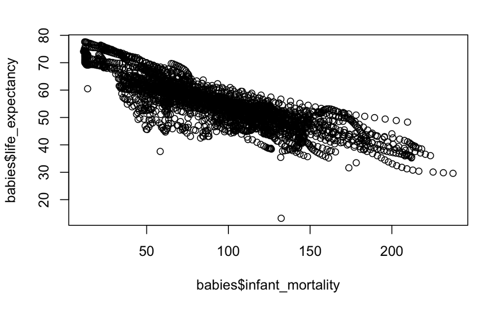

```r
plot(x = babies$infant_mortality, y = babies$life_expectancy, type = "p")
```

There is a negative correlation between infant mortality and life expectancy.

Graph the total population data with life expectancy on the y-axis

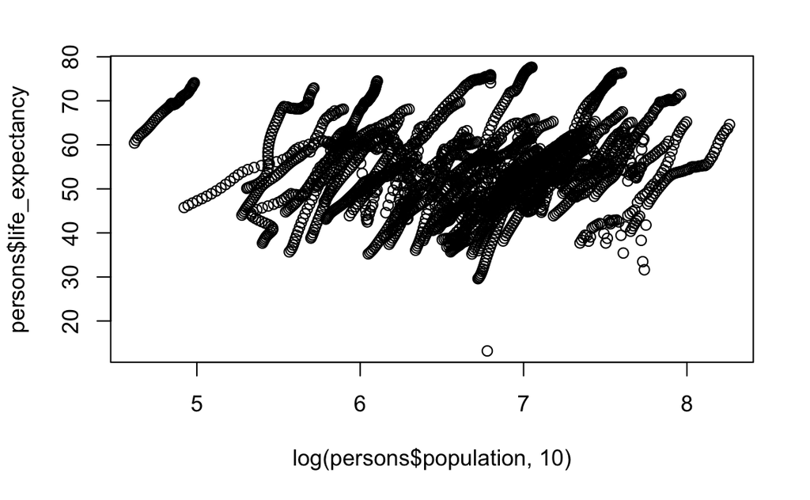

```r
plot(x = log(persons$population, 10), y = persons$life_expectancy)
```

There is a positive corelation between population and life expectancy. There are individual streaks of data because Africa is composed of many different countries, each of which with their own populations and life expectancy data. I hypothesize that the streaks correspond to specific countries.